# Question 4

## Are number of exons in a given transcript statistically significant to the transcript length

Every transcript RNA has a specific number of exons and a length. To determine whether the number of exons of a transcript RNA has a correlation to its length, we use a linear regression model. In this case, the independet variable is num_exons, and the dependent variable is length.

We start by stating our hypotheses:

**H0 : Number of exons IS NOT statistically significant to length**

**H1 : Number of exons IS statistically significant to length**

## Loading tidyverse

```r
library(tidyverse)
```

## Loading and preparing our data

Since we do not have a length variable, we create one by calculating the difference of the transcript's start and end.

```r
ESCn1 <- read.csv("ESCn1_version3.csv")
ESCn1 <- mutate(ESCn1, length = ESCn1$end - ESCn1$start)
```

## Visualizing our data

We will use a scatter plot to visualize our data and the relationship between the number of exons in a transcript and the transcript length.

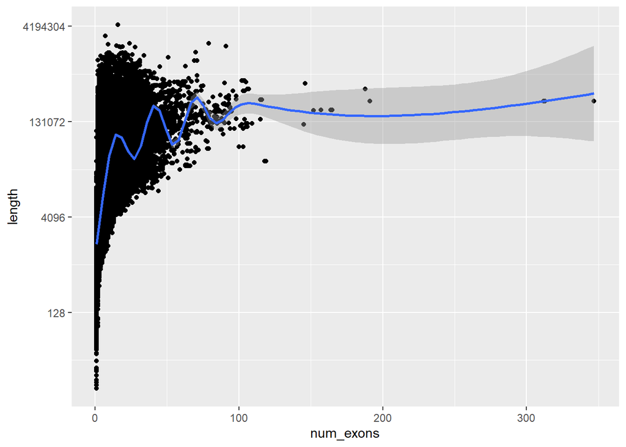

```r
ggplot(data = ESCn1, mapping = aes(x = num_exons, y = length)) +
    geom_point() +
    geom_smooth(mapping = aes(x = num_exons, y = length)) +
    scale_y_continuous(trans = 'log2')
```

Here is the same plot, but excluding our outliers.

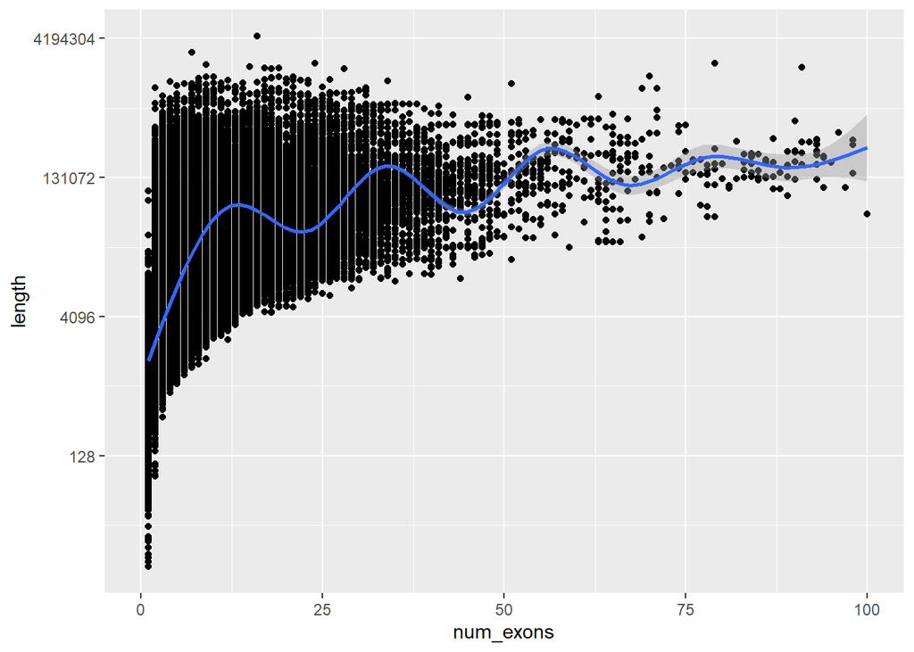

```r
ggplot(data = ESCn1, mapping = aes(x = num_exons, y = length)) +
  geom_point() +
  geom_smooth(mapping = aes(x = num_exons, y = length)) +
  scale_y_continuous(trans = 'log2') +
  scale_x_continuous(limits = c(0, 100))
```

## Correlation test

Since the sample size is much larger than 30, we can assume that both variables are normally distributed. This allows us to use the Pearson method.

```r
cor.test(ESCn1$num_exons, ESCn1$length, method = "pearson")
```

```
##
##  Pearson's product-moment correlation
##
## data:  ESCn1$num_exons and ESCn1$length
## t = 171.28, df = 156233, p-value < 2.2e-16
## alternative hypothesis: true correlation is not equal to 0
## 95 percent confidence interval:
##  0.3934213 0.4017708
## sample estimates:
##       cor
## 0.3976043
```

The result of the correlation test gives a p-value of *<2.2e-16* which is smaller than alpha, so we reject the null hypothesis, meaning that the two variables have a statistically linear relationship. But even though that is the case, the correlation is a very low positive one at *0.3976043*.

## Linear Regression analysis

```r
model <- lm(length ~ num_exons, data = ESCn1)
summary(model)
```

```
##
## Call:
## lm(formula = length ~ num_exons, data = ESCn1)
##
## Residuals:
##      Min       1Q   Median       3Q      Max
## -1093801   -16790    -9563    -5477  4366705
##
## Coefficients:
##             Estimate Std. Error t value Pr(>|t|)
## (Intercept)   5140.3      235.4   21.83   <2e-16 ***
## num_exons     3939.9       23.0  171.28   <2e-16 ***
## ---
## Signif. codes:  0 '***' 0.001 '**' 0.01 '*' 0.05 '.' 0.1 ' ' 1
##
## Residual standard error: 71920 on 156233 degrees of freedom
## Multiple R-squared:  0.1581, Adjusted R-squared:  0.1581
## F-statistic: 2.934e+04 on 1 and 156233 DF,  p-value: < 2.2e-16
```

The result of the linear regression model further supports our findings that the number of exons in a transcript and the transcript's length are statistically significant, since the given p-value is *<2e-16*. But again, even though the two variables are statistically significant, it doesn't mean that the number of exons is an accurate predictor of length. This is shown in the R-squared value, which is only *0.1581*.  
Given our coefficients, the linear model equation is *Length = 5140.3 + 3939.9(num_exons)*.

## Final Outcomes and Analysis

### [Question 1 Report](http://www.itss.brockport.edu/~jlee7/csc435/question1.html)

### [Question 2 Report](http://www.itss.brockport.edu/~jlee7/csc435/question2.html)

### [Question 3 Report](http://www.itss.brockport.edu/~jlee7/csc435/question3.html)

### [Homepage](http://www.itss.brockport.edu/~jlee7/csc435/index.html)

### [Question 5 Report](http://www.itss.brockport.edu/~jlee7/csc435/question5.html)